# Phylogenetic analysis of isolated microalgae from Ecuador

Macarena Mellado Mallea

2025-11-01

**1. Introduction** This document contains the R code and results of the phylogenetic analysis performed on microalgae isolates obtained from Ecuador, and concludes with a comparative analysis of carotenoid production among the isolates.

**2. Data preparation** The following libraries are required for the analysis.

```r
library(Biostrings)
library(msa)
library(ape)
library(phangorn)
library(ggtree)
library(lme4)
library(emmeans)
library(car)
library(FSA)
library(dplyr)
library(tidyr)
library(ggplot2)
```

The nucleotide sequences used in this analysis were imported from the file `tree_sequences.txt`.  
Each sequence corresponds to a microalgae isolate or a reference strain obtained from GenBank.

```r
# Load DNA sequences from text file
seqs_all <- readDNAStringSet("tree_sequences.txt")

widths <- width(seqs_all)


# Retrieve the sequence length (in base pairs) of each isolate
isolates <- c("PM-UPSE-016 PX440405.1",
              "PM018 MZ031041.1",
              "PM-UPSE-022 PX440406.1",
              "PM-UPSE-006 PX440403.1",
              "PM-UPSE-007 PX440404.1")

isolates_lengths <- widths[names(seqs_all) %in% isolates]
isolates_lengths
```

```
## [1]  516 1071  489  527  632
```

The code above reads all DNA sequences and computes their lengths, allowing us to verify that all sequences are of comparable size before performing multiple sequence alignment. The isolate PM-UPSE-022 PX440406.1 was the shortest sequence and was used as a reference to define the sequence length threshold for the analyses.

**3. Multiple sequence alignment using MUSCLE**

The multiple sequence alignment was converted to the DNAbin format using the msaConvert() function, which allows further analysis with the ape package. The isolate PM-UPSE-022 PX440406.1 — identified as the shortest sequence — was used as the reference sequence for subsequent distance calculations.

```r
aligned_all <- msa(seqs_all, method = "Muscle")

# Convert alignment to DNAbin format (for distance calculations)
aligned_dnabin_all <- msaConvert(aligned_all, type = "ape::DNAbin")

# Select the shortest sequence (PM-UPSE-022 PX440406.1) as the reference
ref_seq_all <- aligned_dnabin_all["PM-UPSE-022 PX440406.1", ]
```

The reference sequence was converted to character format to identify positions without gaps. All columns corresponding to gaps (“-”) in the reference sequence were removed from the alignment using the which() function. This trimming step ensures that only homologous, non-gap positions are retained for subsequent phylogenetic analyses, resulting in an effective alignment length of 489 bp.

```r
# Convert reference sequence to character format
ref_seq_all <- as.character(ref_seq_all)

# Identify positions without gaps ("-")
positions_no_gap_all <- which(ref_seq_all != "-")

# Trim all sequences keeping only non-gap positions
aligned_dnabin_all_trimmed <- aligned_dnabin_all[, positions_no_gap_all]

# Check the new alignment length
length_trimmed_all <- ncol(aligned_dnabin_all_trimmed)
print(length_trimmed_all)
```

```
## [1] 489
```

**4.Phylogenetic distance calculation and model selection**

The alignment was first converted to a phyDat object to perform likelihood-based analyses. A distance matrix was computed to evaluate genetic divergence among isolates, and a preliminary Neighbor-Joining (NJ) tree was generated to provide a starting topology. Model selection was carried out using the modelTest() function implemented in phangorn, which compared six common substitution models. Based on the BIC criterion, the model with the lowest BIC value was chosen as the best-fitting model for subsequent maximum likelihood phylogenetic reconstruction.

```r
# Conversion to phyDat object
data_phydat_all <- phyDat(aligned_dnabin_all_trimmed, type = "DNA")

# Distance matrix calculation
dm_dna_all <- dist.dna(aligned_dnabin_all)

# Neighbor-Joining tree construction
treeNJ_all <- NJ(dm_dna_all)
treeNJ_all$tip.label <- names(data_phydat_all)  # corregir etiquetas

# Model selection for ML analysis
fit_all <- pml(treeNJ_all, data = data_phydat_all)

mt_all <- modelTest(fit_all, model = c("JC", "K80", "F81", "HKY", "SYM", "GTR"), control = pml.control(trace = 0))

# Display model comparison results (AIC, BIC, logLik)
print(mt_all)
```

```
##         Model df    logLik      AIC          AICw     AICc         AICcw
## 1          JC 89 -4777.556 9733.111 1.389818e-127 9773.262 1.910536e-125
## 2        JC+I 90 -4652.366 9484.731  1.196772e-73 9525.887  9.951490e-72
## 3     JC+G(4) 90 -4586.561 9353.121  4.537066e-45 9394.277  3.772697e-43
## 4   JC+G(4)+I 91 -4586.624 9355.247  1.566933e-45 9397.424  7.822020e-44
## 5         K80 90 -4703.482 9586.964  7.556611e-96 9628.120  6.283533e-94
## 6       K80+I 91 -4574.710 9331.421  2.338559e-40 9373.597  1.167392e-38
## 7    K80+G(4) 91 -4503.473 9188.946  2.027862e-09 9231.122  1.012295e-07
## 8  K80+G(4)+I 92 -4503.538 9191.076  6.988343e-10 9234.288  2.078366e-08
## 9         F81 92 -4780.982 9745.964 2.248984e-130 9789.176 6.688583e-129
## 10      F81+I 93 -4661.403 9508.806  7.082409e-79 9553.069  1.245289e-77
## 11   F81+G(4) 93 -4597.440 9380.880  4.255829e-51 9425.143  7.482957e-50
## 12 F81+G(4)+I 94 -4597.487 9382.974  1.493797e-51 9428.304  1.540845e-50
## 13        HKY 93 -4710.122 9606.244 4.918661e-100 9650.507  8.648403e-99
## 14      HKY+I 94 -4578.574 9345.148  2.444335e-43 9390.478  2.521320e-42
```

[output cut: 35 more lines]

```r
# Select best model according to BIC
best_model6 <- mt_all[which.min(mt_all[,"BIC"]), ]

cat("The best-fitting model was selected based on the lowest BIC value (BIC =", best_model6$BIC,
    ", AIC =", best_model6$AIC, ").\n")
```

```
## The best-fitting model was selected based on the lowest BIC value (BIC = 9560.392 , AIC = 9149.541 ).
```

**5. Maximum likelihood tree construction under the GTR + Γ model**

The initial GTR model was optimized using maximum likelihood estimation, incorporating rate heterogeneity among sites modeled with a Gamma distribution (k = 4 rate categories). The optimization was performed with stochastic tree rearrangements to improve likelihood convergence.

The optimized ML tree was obtained under the GTR + Γ model, allowing for rate variation among sites. The optimization improved the likelihood of the tree topology derived from the Neighbor-Joining starting tree.

```r
# Initial maximum likelihood model setup
fit_all <- pml(treeNJ_all, data = data_phydat_all, k = 4)

# Set random seed for reproducibility
set.seed(123)

# Optimize the GTR model with Gamma rate heterogeneity
fit_opt_all <- optim.pml(fit_all, model = "GTR",
                         optInv = FALSE, optGamma = TRUE,
                         rearrangement = "stochastic",
                         control = pml.control(trace = 0))
```

**6. Rooting and bootstrap support assignment**

The optimized maximum likelihood (ML) tree was rooted using Porphyra umbilicalis JN029234.1 as the outgroup to establish the evolutionary direction among taxa. To evaluate the statistical support for each node of the optimized ML tree, a bootstrap analysis was conducted using 100 pseudo-replicates. The function bootstrap.pml() from the phangorn package was applied with the NNI option enabled to refine local tree topologies. The resulting set of bootstrap trees was used to estimate node support values in the final phylogeny. Subsequently, the bootstrap support values were assigned to the corresponding internal nodes of the tree to assess the robustness of the inferred clades.

```r
# Root the optimized ML tree using the outgroup
tree_all <- root(fit_opt_all$tree,
                 outgroup = "Porphyra umbilicalis JN029234.1(outgroup)",
                 resolve.root = TRUE)

# Random seed set for reproducibility of bootstrap results
set.seed(123)

# Bootstrap analysis of node support
bs_all <- bootstrap.pml(fit_opt_all, bs = 100, optNni = TRUE,
                        control = pml.control(trace = 0))

# Compute bootstrap support values for the rooted tree
bs_support <- prop.clades(tree_all, bs_all)

# Assign bootstrap values to tree nodes
tree_all$node.label <- bs_support
```

**7.Visualization of the maximum likelihood tree**

The optimized and rooted ML tree was visualized using the `ggtree` package, which allows the customization of labels, colors, and bootstrap values for clear graphical representation.  
In this figure, *Porphyra umbilicalis* JN029234.1 was used as the outgroup (in green), while the Ecuadorian isolates were highlighted in blue.

```r
# Identification of Outgroup and Highlighted Tips
outgroup_name <- "Porphyra umbilicalis JN029234.1(outgroup)"
highlight_tips <- c("PM-UPSE-007 PX440404.1", "PM-UPSE-006 PX440403.1", "PM-UPSE-022 PX440406.1", "PM-UPSE-016 PX440405.1", "PM018 MZ031041.1")
```

This script extracts bootstrap values and descendant tips from internal nodes of a phylogenetic tree, organizes the data, and plots the tree with node numbers using `ggtree`.

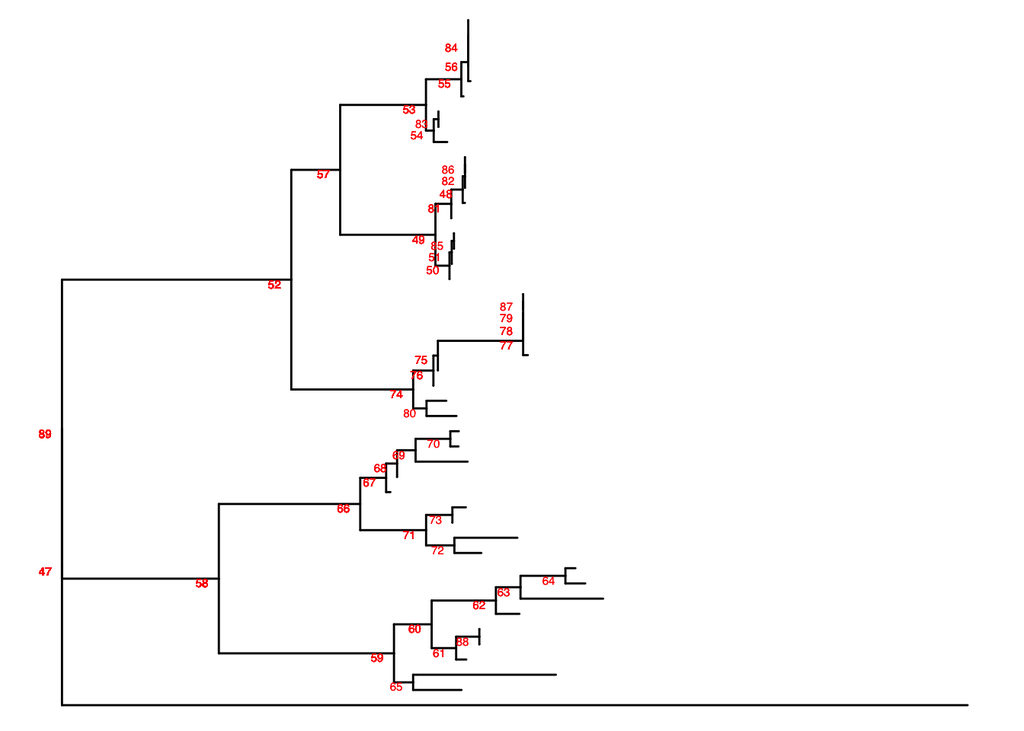

```r
# Identify all internal nodes of the tree
nodos_internos <- (Ntip(tree_all) + 1):(Ntip(tree_all) + tree_all$Nnode)

# Create an empty data frame to store node information
result <- data.frame(
  nodo = integer(), # node number
  bootstrap = numeric(), # bootstrap value
  tips = character(), # descendant tip labels
  stringsAsFactors = FALSE
)

# Loop through each internal node and record its descendant tips
for (node in nodos_internos) {
  tips_desc <- tree_all$tip.label[Descendants(tree_all, node, type = "tips")[[1]]]
  result <- rbind(result, data.frame(
    nodo = node,
    bootstrap = tree_all$node.label[node - Ntip(tree_all)],
    tips = paste(tips_desc, collapse = ", ")
  ))
}

# Organize the data into a tidy table: one row per tip, sorted by node
tabla_nodos <- result %>%
  separate_rows(tips, sep = ", ") %>%
  arrange(nodo)

# Obtain coordinates of nodes and tips using fortify
tree_df <- fortify(tree_all)

# Merge node information with coordinates
tabla_nodos <- tabla_nodos %>%
  left_join(tree_df, by = c("nodo" = "node"))

# Plot the tree and display node numbers
ggtree(tree_all) +
  geom_text2(data = tabla_nodos,
             aes(x = x, y = y, label = nodo),
             hjust = 1.8, size = 2, vjust = 1,  color = "red")
```

The phylogenetic tree was visualized using ggtree, with bootstrap support values displayed for internal nodes except for those located in densely branched regions, where label placement would be difficult and potentially unclear. Tip labels were colored according to their category, with the outgroup highlighted in dark green, selected taxa of interest in royal blue, and all other taxa in black. Key clades were visually emphasized using semi-transparent colored highlights, allowing for easy identification of major evolutionary groups. The tree was plotted with a theme suitable for phylogenetic trees and axes, with adjustments to the X-axis and coordinate clipping to ensure that all labels and graphical elements were fully visible.

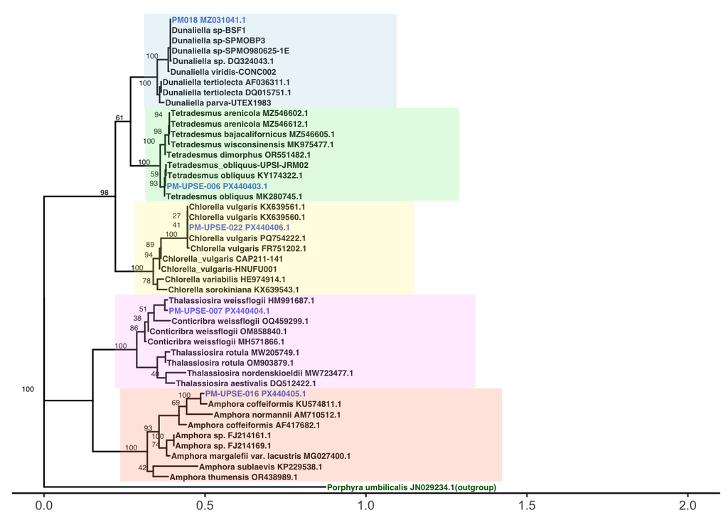

```r
# Plot the tree
# Define the internal nodes to be hidden from the plot.
# These nodes correspond to internal branches located in regions of the tree with multiple overlapping branches, where displaying their bootstrap values would be difficult to position and interpret clearly.

nodos_ocultar <- c(56, 53, 54, 58, 62, 70, 71, 73, 82,84, 85, 87)

# Create the phylogenetic tree plot.
# The basic tree structure is generated using the ggtree() function.
p <- ggtree(tree_all) +
  # Add bootstrap support values to internal nodes.
  # Nodes listed in 'nodos_ocultar' and terminal tips are excluded.
  # Text positions are slightly adjusted to avoid overlap.
  geom_text2(
    aes(subset = !isTip & !is.na(label) & !(node %in% nodos_ocultar),
        label = label),
    hjust = 1.8,
    nudge_y = 0.4,
    size = 1.8
  ) +
  # Add tip labels (species names or taxa).
  # Labels are colored according to their category:
  # - Dark green for the outgroup
  # - Royal blue for highlighted taxa
  # - Black for all others
  geom_tiplab(
    aes(color = ifelse(label == outgroup_name,
                       "outgroup",
                       ifelse(label %in% highlight_tips, "highlight", "other"))),
    size = 2,
    fontface = "bold"
  ) +
  # Manually assign colors to each category.
  # The legend is hidden (guide = "none") to keep the plot clean.
  scale_color_manual(values = c("outgroup" = "darkgreen",
                                "highlight" = "royalblue",
                                "other" = "black"),
                                 guide = "none") +
  # --- CLADE HIGHLIGHT COLORS ---
  # Visually highlight specific clades with soft, semi-transparent colors.
  # Each 'geom_hilight()' call colors the area under a selected internal node.
  geom_hilight(node = 53, fill = "lightblue", alpha = 0.25, extend = 0.7) +
  geom_hilight(node = 49, fill = "lightgreen", alpha = 0.25, extend = 0.9) +
  geom_hilight(node = 74, fill = "khaki1", alpha = 0.25, extend = 0.7) +
  geom_hilight(node = 66, fill = "plum1", alpha = 0.25, extend = 0.9) +
  geom_hilight(node = 59, fill = "lightsalmon", alpha = 0.25, extend = 0.9) +
  # Apply a tree-specific theme with axes.
  theme_tree2() +
  # Prevent elements from being cropped outside the visible area.
  coord_cartesian(clip = "off") +
  # Adjust the X-axis range to ensure that labels and text are fully visible.
  xlim(0, 2)

# Display the final phylogenetic tree with highlighted clades.
print(p)
```

8. Comparison of Carotenoid Production Among Microalgae Isolates This section compares carotenoid production among the microalgae isolates. Carotenoid concentration data obtained from four replicate flasks were analyzed. A linear mixed-effects model was initially fitted, considering Microalga as a fixed effect and Matraz (flask) as a random effect. However, since the residuals did not meet the assumption of normality, a non-parametric approach was applied instead. The Kruskal–Wallis test was used to assess overall differences in carotenoid production among the isolates, followed by Dunn’s post-hoc test with Bonferroni adjustment to identify significant pairwise differences.

```r
# Data
microalga <- c("PM016", "PM0018", "PM022", "PM006", "PM007")
matraz1 <- c(0.5144, 1.5957, 0.7626, 0.2256, 0.2304)
matraz2 <- c(0.5426, 1.5964, 0.7664, 0.2237, 0.2305)
matraz3 <- c(0.5364, 1.6014, 0.7632, 0.2247, 0.2300)
matraz4 <- c(0.5390, 1.6058, 0.7688, 0.2247, 0.2297)

# Create a data frame with carotenoid measurements for each microalga.
# Rows correspond to isolates, columns correspond to replicate flasks.
carotenos <- data.frame(
  Microalga = microalga,
  Matraz1 = matraz1,
  Matraz2 = matraz2,
  Matraz3 = matraz3,
  Matraz4 = matraz4
)

# Convert to long format
carotenos_largo <- carotenos %>%
  pivot_longer(
    cols = starts_with("Matraz"),
    names_to = "Matraz",
    values_to = "Valor"
  )

# --- Linear Mixed-Effects Model ---
# Microalga as a fixed effect, Matraz as a random effect
modelo <- lmer(Valor ~ Microalga + (1|Matraz), data = carotenos_largo)
summary(modelo)
```

```
## Linear mixed model fit by REML ['lmerMod']
## Formula: Valor ~ Microalga + (1 | Matraz)
##    Data: carotenos_largo
##
## REML criterion at convergence: -103.3
##
## Scaled residuals:
##      Min       1Q   Median       3Q      Max
## -2.86728 -0.26845 -0.03381  0.42362  1.53820
##
## Random effects:
##  Groups   Name        Variance  Std.Dev.
##  Matraz   (Intercept) 4.773e-06 0.002185
##  Residual             3.389e-05 0.005821
## Number of obs: 20, groups:  Matraz, 4
##
## Fixed effects:
##                 Estimate Std. Error t value
## (Intercept)     1.599825   0.003109   514.6
## MicroalgaPM006 -1.375150   0.004116  -334.1
## MicroalgaPM007 -1.369675   0.004116  -332.7
## MicroalgaPM016 -1.066725   0.004116  -259.1
## MicroalgaPM022 -0.834575   0.004116  -202.7
##
## Correlation of Fixed Effects:
##             (Intr) MPM006 MPM007 MPM016
## MicrlgPM006 -0.662
## MicrlgPM007 -0.662  0.500
## MicrlgPM016 -0.662  0.500  0.500
## MicrlgPM022 -0.662  0.500  0.500  0.500
```

```r
# --- Comparaciones múltiples (Tukey HSD) ---
emmeans(modelo, pairwise ~ Microalga, adjust = "tukey")
```

```
## $emmeans
##  Microalga emmean      SE    df lower.CL upper.CL
##  PM0018    1.5998 0.00311 14.14   1.5932   1.6065
##  PM006     0.2247 0.00311 14.14   0.2180   0.2313
##  PM007     0.2301 0.00311 14.14   0.2235   0.2368
##  PM016     0.5331 0.00311 14.14   0.5264   0.5398
##  PM022     0.7652 0.00311 14.14   0.7586   0.7719
##
## Degrees-of-freedom method: kenward-roger
## Confidence level used: 0.95
##
## $contrasts
##  contrast       estimate      SE df  t.ratio p.value
##  PM0018 - PM006  1.37515 0.00412 12  334.069  <.0001
##  PM0018 - PM007  1.36967 0.00412 12  332.739  <.0001
##  PM0018 - PM016  1.06672 0.00412 12  259.142  <.0001
##  PM0018 - PM022  0.83457 0.00412 12  202.746  <.0001
##  PM006 - PM007  -0.00547 0.00412 12   -1.330  0.6792
##  PM006 - PM016  -0.30843 0.00412 12  -74.926  <.0001
##  PM006 - PM022  -0.54058 0.00412 12 -131.323  <.0001
##  PM007 - PM016  -0.30295 0.00412 12  -73.597  <.0001
##  PM007 - PM022  -0.53510 0.00412 12 -129.993  <.0001
##  PM016 - PM022  -0.23215 0.00412 12  -56.397  <.0001
##
## Degrees-of-freedom method: kenward-roger
## P value adjustment: tukey method for comparing a family of 5 estimates
```

```r
# --- Verificación de supuestos ---
# Normalidad de residuos
shapiro.test(resid(modelo))
```

```
##
##  Shapiro-Wilk normality test
##
## data:  resid(modelo)
## W = 0.82574, p-value = 0.002146
```

```r
# Homogeneidad de varianzas
leveneTest(Valor ~ Microalga, data = carotenos_largo)
```

|  | Df | F value | Pr(>F) |
| --- | --- | --- | --- |
| group | 4 | 1.569011 | 0.2335219 |
|  | 15 | NA | NA |

```r
# As the residuals did not meet the assumption of normality, the mixed-effects model may not provide fully reliable parametric inferences. Consequently, a non-parametric analysis (Kruskal–Wallis test followed by Dunn’s post-hoc test) was conducted to compare carotenoid production among the microalgae isolates.


# Non-parametric analysis

# Perform a Kruskal-Wallis test to compare carotenoid values among microalgae
kruskal_test <- kruskal.test(Valor ~ Microalga, data = carotenos_largo)
kruskal_test
```

```
##
##  Kruskal-Wallis rank sum test
##
## data:  Valor by Microalga
## Kruskal-Wallis chi-squared = 18.299, df = 4, p-value = 0.001078
```

```r
# Post-hoc pairwise comparisons using Dunn's test with Bonferroni adjustment

dunnTest(Valor ~ Microalga, data = carotenos_largo, method = "bonferroni")
```

```
##        Comparison          Z      P.unadj       P.adj
## 1  PM0018 - PM006  3.8261702 0.0001301523 0.001301523
## 2  PM0018 - PM007  2.8696277 0.0041095539 0.041095539
## 3   PM006 - PM007 -0.9565426 0.3387981941 1.000000000
## 4  PM0018 - PM016  1.9130851 0.0557371570 0.557371570
## 5   PM006 - PM016 -1.9130851 0.0557371570 0.557371570
## 6   PM007 - PM016 -0.9565426 0.3387981941 1.000000000
## 7  PM0018 - PM022  0.9565426 0.3387981941 1.000000000
## 8   PM006 - PM022 -2.8696277 0.0041095539 0.041095539
## 9   PM007 - PM022 -1.9130851 0.0557371570 0.557371570
## 10  PM016 - PM022 -0.9565426 0.3387981941 1.000000000
```